# gapminder-wrangle

梁凯毅

#利用“dplyr”进行数据操作

readr::read_csv()前面是包，后面是函数。view打开一个table查看全部数据。

```r
gapminder<-read_csv("../data/gapminder.csv")
view(gapminder)
head(gapminder,10)
```

```
## # A tibble: 10 x 6
##    country      year      pop continent lifeExp gdpPercap
##    <chr>       <dbl>    <dbl> <chr>       <dbl>     <dbl>
##  1 Afghanistan  1952  8425333 Asia         28.8      779.
##  2 Afghanistan  1957  9240934 Asia         30.3      821.
##  3 Afghanistan  1962 10267083 Asia         32.0      853.
##  4 Afghanistan  1967 11537966 Asia         34.0      836.
##  5 Afghanistan  1972 13079460 Asia         36.1      740.
##  6 Afghanistan  1977 14880372 Asia         38.4      786.
##  7 Afghanistan  1982 12881816 Asia         39.9      978.
##  8 Afghanistan  1987 13867957 Asia         40.8      852.
##  9 Afghanistan  1992 16317921 Asia         41.7      649.
## 10 Afghanistan  1997 22227415 Asia         41.8      635.
```

```r
tail(gapminder)
```

```
## # A tibble: 6 x 6
##   country   year      pop continent lifeExp gdpPercap
##   <chr>    <dbl>    <dbl> <chr>       <dbl>     <dbl>
## 1 Zimbabwe  1982  7636524 Africa       60.4      789.
## 2 Zimbabwe  1987  9216418 Africa       62.4      706.
## 3 Zimbabwe  1992 10704340 Africa       60.4      693.
## 4 Zimbabwe  1997 11404948 Africa       46.8      792.
## 5 Zimbabwe  2002 11926563 Africa       40.0      672.
## 6 Zimbabwe  2007 12311143 Africa       43.5      470.
```

```r
str(gapminder)
```

```
## tibble [1,704 x 6] (S3: spec_tbl_df/tbl_df/tbl/data.frame)
##  $ country  : chr [1:1704] "Afghanistan" "Afghanistan" "Afghanistan" "Afghanistan" ...
##  $ year     : num [1:1704] 1952 1957 1962 1967 1972 ...
##  $ pop      : num [1:1704] 8425333 9240934 10267083 11537966 13079460 ...
##  $ continent: chr [1:1704] "Asia" "Asia" "Asia" "Asia" ...
##  $ lifeExp  : num [1:1704] 28.8 30.3 32 34 36.1 ...
##  $ gdpPercap: num [1:1704] 779 821 853 836 740 ...
##  - attr(*, "spec")=
##   .. cols(
##   ..   country = col_character(),
##   ..   year = col_double(),
##   ..   pop = col_double(),
##   ..   continent = col_character(),
##   ..   lifeExp = col_double(),
##   ..   gdpPercap = col_double()
##   .. )
```

dplyr函数：filter()选行，select()选列，mutate()生成新变量，summarise()综合数据，arrange()重排。在这些函数中调用时不需要引号和$符号。

filter()：take 1.data 2.logical expressions and return the TRUE rows.

```r
filter(gapminder,lifeExp<29)
```

```
## # A tibble: 2 x 6
##   country      year     pop continent lifeExp gdpPercap
##   <chr>       <dbl>   <dbl> <chr>       <dbl>     <dbl>
## 1 Afghanistan  1952 8425333 Asia         28.8      779.
## 2 Rwanda       1992 7290203 Africa       23.6      737.
```

```r
filter(gapminder,country=="China")
```

```
## # A tibble: 12 x 6
##    country  year         pop continent lifeExp gdpPercap
##    <chr>   <dbl>       <dbl> <chr>       <dbl>     <dbl>
##  1 China    1952  556263528. Asia         44        400.
##  2 China    1957  637408000  Asia         50.5      576.
##  3 China    1962  665770000  Asia         44.5      488.
##  4 China    1967  754550000  Asia         58.4      613.
##  5 China    1972  862030000  Asia         63.1      677.
##  6 China    1977  943455000  Asia         64.0      741.
##  7 China    1982 1000281000  Asia         65.5      962.
##  8 China    1987 1084035000  Asia         67.3     1379.
##  9 China    1992 1164970000  Asia         68.7     1656.
## 10 China    1997 1230075000  Asia         70.4     2289.
## 11 China    2002 1280400000  Asia         72.0     3119.
## 12 China    2007 1318683096  Asia         73.0     4959.
```

```r
filter(gapminder,country %in% c("Mexico","Peru"))
```

```
## # A tibble: 24 x 6
##    country  year      pop continent lifeExp gdpPercap
##    <chr>   <dbl>    <dbl> <chr>       <dbl>     <dbl>
##  1 Mexico   1952 30144317 Americas     50.8     3478.
##  2 Mexico   1957 35015548 Americas     55.2     4132.
##  3 Mexico   1962 41121485 Americas     58.3     4582.
##  4 Mexico   1967 47995559 Americas     60.1     5755.
##  5 Mexico   1972 55984294 Americas     62.4     6809.
##  6 Mexico   1977 63759976 Americas     65.0     7675.
##  7 Mexico   1982 71640904 Americas     67.4     9611.
##  8 Mexico   1987 80122492 Americas     69.5     8688.
##  9 Mexico   1992 88111030 Americas     71.5     9472.
## 10 Mexico   1997 95895146 Americas     73.7     9767.
## # ... with 14 more rows
```

```r
filter(gapminder,country=="Mexico",year==2002)
```

```
## # A tibble: 1 x 6
##   country  year       pop continent lifeExp gdpPercap
##   <chr>   <dbl>     <dbl> <chr>       <dbl>     <dbl>
## 1 Mexico   2002 102479927 Americas     74.9    10742.
```

```r
mean(filter(gapminder,country=="Brazil",year>=1987,year<=2007)$lifeExp)
```

```
## [1] 69.0092
```

select():select multiple columns.（这个函数会有冲突，所以用dplyr::select()）。可以用“-”来删去columns

```r
dplyr::select(gapminder,year,country,lifeExp)
```

```
## # A tibble: 1,704 x 3
##     year country     lifeExp
##    <dbl> <chr>         <dbl>
##  1  1952 Afghanistan    28.8
##  2  1957 Afghanistan    30.3
##  3  1962 Afghanistan    32.0
##  4  1967 Afghanistan    34.0
##  5  1972 Afghanistan    36.1
##  6  1977 Afghanistan    38.4
##  7  1982 Afghanistan    39.9
##  8  1987 Afghanistan    40.8
##  9  1992 Afghanistan    41.7
## 10  1997 Afghanistan    41.8
## # ... with 1,694 more rows
```

```r
dplyr::select(gapminder,-continent,-lifeExp)
```

```
## # A tibble: 1,704 x 4
##    country      year      pop gdpPercap
##    <chr>       <dbl>    <dbl>     <dbl>
##  1 Afghanistan  1952  8425333      779.
##  2 Afghanistan  1957  9240934      821.
##  3 Afghanistan  1962 10267083      853.
##  4 Afghanistan  1967 11537966      836.
##  5 Afghanistan  1972 13079460      740.
##  6 Afghanistan  1977 14880372      786.
##  7 Afghanistan  1982 12881816      978.
##  8 Afghanistan  1987 13867957      852.
##  9 Afghanistan  1992 16317921      649.
## 10 Afghanistan  1997 22227415      635.
## # ... with 1,694 more rows
```

```r
gap_cambodia<-filter(gapminder,country=="Cambodia")
gap_combodia<-dplyr::select(gap_cambodia,-continent,-lifeExp)
gap_combodia
```

```
## # A tibble: 12 x 4
##    country   year      pop gdpPercap
##    <chr>    <dbl>    <dbl>     <dbl>
##  1 Cambodia  1952  4693836      368.
##  2 Cambodia  1957  5322536      434.
##  3 Cambodia  1962  6083619      497.
##  4 Cambodia  1967  6960067      523.
##  5 Cambodia  1972  7450606      422.
##  6 Cambodia  1977  6978607      525.
##  7 Cambodia  1982  7272485      624.
##  8 Cambodia  1987  8371791      684.
##  9 Cambodia  1992 10150094      682.
## 10 Cambodia  1997 11782962      734.
## 11 Cambodia  2002 12926707      896.
## 12 Cambodia  2007 14131858     1714.
```

pipe %>% operator：传递数据，可以连续使用.

```r
gapminder%>%head(3)
```

```
## # A tibble: 3 x 6
##   country      year      pop continent lifeExp gdpPercap
##   <chr>       <dbl>    <dbl> <chr>       <dbl>     <dbl>
## 1 Afghanistan  1952  8425333 Asia         28.8      779.
## 2 Afghanistan  1957  9240934 Asia         30.3      821.
## 3 Afghanistan  1962 10267083 Asia         32.0      853.
```

```r
gap_cambodia<-gapminder %>% filter(country=="Cambodia") %>%
  dplyr::select(-continent,-lifeExp)
gap_combodia
```

```
## # A tibble: 12 x 4
##    country   year      pop gdpPercap
##    <chr>    <dbl>    <dbl>     <dbl>
##  1 Cambodia  1952  4693836      368.
##  2 Cambodia  1957  5322536      434.
##  3 Cambodia  1962  6083619      497.
##  4 Cambodia  1967  6960067      523.
##  5 Cambodia  1972  7450606      422.
##  6 Cambodia  1977  6978607      525.
##  7 Cambodia  1982  7272485      624.
##  8 Cambodia  1987  8371791      684.
##  9 Cambodia  1992 10150094      682.
## 10 Cambodia  1997 11782962      734.
## 11 Cambodia  2002 12926707      896.
## 12 Cambodia  2007 14131858     1714.
```

mutate():添加新的列。 function in mutate: + , - , * , / , %/% , %% , log() , log2() ,log10() , lead() , lag()….

```r
gapminder %>% mutate(gdp = pop*gdpPercap)
```

```
## # A tibble: 1,704 x 7
##    country      year      pop continent lifeExp gdpPercap          gdp
##    <chr>       <dbl>    <dbl> <chr>       <dbl>     <dbl>        <dbl>
##  1 Afghanistan  1952  8425333 Asia         28.8      779.  6567086330.
##  2 Afghanistan  1957  9240934 Asia         30.3      821.  7585448670.
##  3 Afghanistan  1962 10267083 Asia         32.0      853.  8758855797.
##  4 Afghanistan  1967 11537966 Asia         34.0      836.  9648014150.
##  5 Afghanistan  1972 13079460 Asia         36.1      740.  9678553274.
##  6 Afghanistan  1977 14880372 Asia         38.4      786. 11697659231.
##  7 Afghanistan  1982 12881816 Asia         39.9      978. 12598563401.
##  8 Afghanistan  1987 13867957 Asia         40.8      852. 11820990309.
##  9 Afghanistan  1992 16317921 Asia         41.7      649. 10595901589.
## 10 Afghanistan  1997 22227415 Asia         41.8      635. 14121995875.
## # ... with 1,694 more rows
```

```r
gapminder %>% filter(continent=="Asia",year==2007) %>% mutate(pop1000 = pop/1000)
```

```
## # A tibble: 33 x 7
##    country          year        pop continent lifeExp gdpPercap  pop1000
##    <chr>           <dbl>      <dbl> <chr>       <dbl>     <dbl>    <dbl>
##  1 Afghanistan      2007   31889923 Asia         43.8      975.   31890.
##  2 Bahrain          2007     708573 Asia         75.6    29796.     709.
##  3 Bangladesh       2007  150448339 Asia         64.1     1391.  150448.
##  4 Cambodia         2007   14131858 Asia         59.7     1714.   14132.
##  5 China            2007 1318683096 Asia         73.0     4959. 1318683.
##  6 Hong Kong China  2007    6980412 Asia         82.2    39725.    6980.
##  7 India            2007 1110396331 Asia         64.7     2452. 1110396.
##  8 Indonesia        2007  223547000 Asia         70.6     3541.  223547
##  9 Iran             2007   69453570 Asia         71.0    11606.   69454.
## 10 Iraq             2007   27499638 Asia         59.5     4471.   27500.
## # ... with 23 more rows
```

group_by():分组

```r
gapminder %>% filter(year==2002) %>% group_by(continent) %>% mutate(cont_pop=sum(pop))
```

```
## # A tibble: 142 x 7
## # Groups:   continent [5]
##    country      year       pop continent lifeExp gdpPercap   cont_pop
##    <chr>       <dbl>     <dbl> <chr>       <dbl>     <dbl>      <dbl>
##  1 Afghanistan  2002  25268405 Asia         42.1      727. 3601802203
##  2 Albania      2002   3508512 Europe       75.7     4604.  578223869
##  3 Algeria      2002  31287142 Africa       71.0     5288.  833723916
##  4 Angola       2002  10866106 Africa       41.0     2773.  833723916
##  5 Argentina    2002  38331121 Americas     74.3     8798.  849772762
##  6 Australia    2002  19546792 Oceania      80.4    30688.   23454829
##  7 Austria      2002   8148312 Europe       79.0    32418.  578223869
##  8 Bahrain      2002    656397 Asia         74.8    23404. 3601802203
##  9 Bangladesh   2002 135656790 Asia         62.0     1136. 3601802203
## 10 Belgium      2002  10311970 Europe       78.3    30486.  578223869
## # ... with 132 more rows
```

summarize():合并？ ungroup():去除group()的效果，但这里已经summarize了, ungroup似乎没有起到效果？ 可以非常有效的用在Homework2中。

```r
gapminder %>% group_by(continent) %>% summarise(cont_pop = sum(pop)) %>% ungroup()
```

```
## # A tibble: 5 x 2
##   continent     cont_pop
##   <chr>            <dbl>
## 1 Africa     6187585961
## 2 Americas   7351438499
## 3 Asia      30507333902.
## 4 Europe     6181115304
## 5 Oceania     212992136
```

```r
gap1<-gapminder %>% group_by(continent,year) %>% summarise(cont_pop = sum(pop))
```

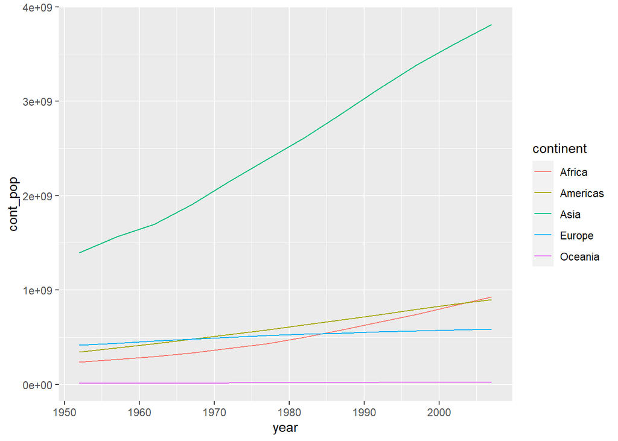

```r
ggplot(data=gap1,aes(x=year,y=cont_pop))+
  geom_line(aes(color=continent))
```

arrange():排序,arrange(desc())是倒叙

```r
gap1 %>%arrange(year)
```

```
## # A tibble: 60 x 3
## # Groups:   continent [5]
##    continent  year    cont_pop
##    <chr>     <dbl>       <dbl>
##  1 Africa     1952  237640501
##  2 Americas   1952  345152446
##  3 Asia       1952 1395357352.
##  4 Europe     1952  418120846
##  5 Oceania    1952   10686006
##  6 Africa     1957  264837738
##  7 Americas   1957  386953916
##  8 Asia       1957 1562780599
##  9 Europe     1957  437890351
## 10 Oceania    1957   11941976
## # ... with 50 more rows
```

```r
gap2<-gapminder %>% group_by(continent,year) %>% mutate(GDP = pop*gdpPercap) %>% summarize(contgdp = sum(GDP))
max(gap2$contgdp)
```

```
## [1] 2.070795e+13
```

```r
gapminder %>% filter(continent=="Asia") %>% group_by(year) %>% summarize(maxlife = max(lifeExp)) %>% arrange(desc(year))
```

```
## # A tibble: 12 x 2
##     year maxlife
##    <dbl>   <dbl>
##  1  2007    82.6
##  2  2002    82
##  3  1997    80.7
##  4  1992    79.4
##  5  1987    78.7
##  6  1982    77.1
##  7  1977    75.4
##  8  1972    73.4
##  9  1967    71.4
## 10  1962    69.4
## 11  1957    67.8
## 12  1952    65.4
```

#数据结构转化：

```r
gap_wide<-readr::read_csv("../data/gapminder_wide.csv")
gapminder<-readr::read_csv("../data/gapminder.csv")
```

gather中的参数只是命名

```r
gap_long<-gap_wide %>% gather(key=obstype_year,value=obs_values)
head(gap_long)
```

```
## # A tibble: 6 x 2
##   obstype_year obs_values
##   <chr>        <chr>
## 1 continent    Africa
## 2 continent    Africa
## 3 continent    Africa
## 4 continent    Africa
## 5 continent    Africa
## 6 continent    Africa
```

```r
tail(gap_long)
```

```
## # A tibble: 6 x 2
##   obstype_year obs_values
##   <chr>        <chr>
## 1 pop_2007     9031088
## 2 pop_2007     7554661
## 3 pop_2007     71158647
## 4 pop_2007     60776238
## 5 pop_2007     20434176
## 6 pop_2007     4115771
```

添加参数确定对哪些值进行变化

```r
gap_long<-gap_wide %>%
  gather(key=obstype_year,value=obs_value,
         dplyr::starts_with("pop"),
         dplyr::starts_with("lifeExp"),
         dplyr::starts_with("gdpPercap"))
head(gap_long)
```

```
## # A tibble: 6 x 4
##   continent country      obstype_year obs_value
##   <chr>     <chr>        <chr>            <dbl>
## 1 Africa    Algeria      pop_1952       9279525
## 2 Africa    Angola       pop_1952       4232095
## 3 Africa    Benin        pop_1952       1738315
## 4 Africa    Botswana     pop_1952        442308
## 5 Africa    Burkina Faso pop_1952       4469979
## 6 Africa    Burundi      pop_1952       2445618
```

```r
tail(gap_long)
```

```
## # A tibble: 6 x 4
##   continent country        obstype_year   obs_value
##   <chr>     <chr>          <chr>              <dbl>
## 1 Europe    Sweden         gdpPercap_2007    33860.
## 2 Europe    Switzerland    gdpPercap_2007    37506.
## 3 Europe    Turkey         gdpPercap_2007     8458.
## 4 Europe    United Kingdom gdpPercap_2007    33203.
## 5 Oceania   Australia      gdpPercap_2007    34435.
## 6 Oceania   New Zealand    gdpPercap_2007    25185.
```

用“-”符号减掉不做变化的列也是同样的效果

```r
gap_long<-gap_wide %>%
  gather(key=obstype_year,value=obs_value,-continent,-country)
```

用separate()函数对一列的数据进行二维化处理

```r
gap_long1<-gap_long %>% separate(obstype_year,into=c("obs_type","year"),sep="_",convert=TRUE)
head(gap_long1)
```

```
## # A tibble: 6 x 5
##   continent country      obs_type   year obs_value
##   <chr>     <chr>        <chr>     <int>     <dbl>
## 1 Africa    Algeria      gdpPercap  1952     2449.
## 2 Africa    Angola       gdpPercap  1952     3521.
## 3 Africa    Benin        gdpPercap  1952     1063.
## 4 Africa    Botswana     gdpPercap  1952      851.
## 5 Africa    Burkina Faso gdpPercap  1952      543.
## 6 Africa    Burundi      gdpPercap  1952      339.
```

```r
tail(gap_long1)
```

```
## # A tibble: 6 x 5
##   continent country        obs_type  year obs_value
##   <chr>     <chr>          <chr>    <int>     <dbl>
## 1 Europe    Sweden         pop       2007   9031088
## 2 Europe    Switzerland    pop       2007   7554661
## 3 Europe    Turkey         pop       2007  71158647
## 4 Europe    United Kingdom pop       2007  60776238
## 5 Oceania   Australia      pop       2007  20434176
## 6 Oceania   New Zealand    pop       2007   4115771
```

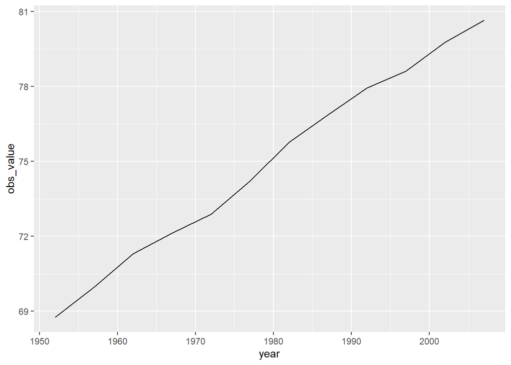

```r
canada_df<-gap_long1 %>% filter(obs_type=="lifeExp",country=="Canada")
ggplot(canada_df,aes(x=year,y=obs_value))+
  geom_line()
```

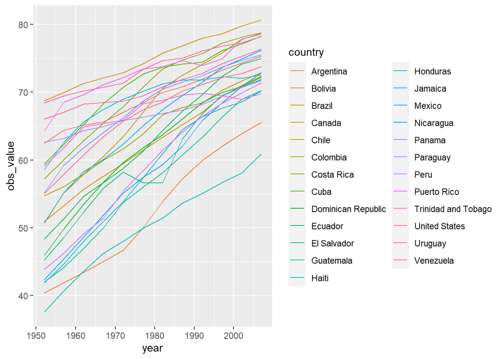

```r
life_df<-gap_long1 %>% filter(obs_type=="lifeExp",continent=="Americas")
ggplot(life_df,aes(x=year,y=obs_value,color=country))+
  geom_line()
```

spread()函数用于将长数据变为宽数据

```r
gap_normal<-gap_long1 %>% spread(obs_type,obs_value)
head(gap_normal)
```

```
## # A tibble: 6 x 6
##   continent country  year gdpPercap lifeExp      pop
##   <chr>     <chr>   <int>     <dbl>   <dbl>    <dbl>
## 1 Africa    Algeria  1952     2449.    43.1  9279525
## 2 Africa    Algeria  1957     3014.    45.7 10270856
## 3 Africa    Algeria  1962     2551.    48.3 11000948
## 4 Africa    Algeria  1967     3247.    51.4 12760499
## 5 Africa    Algeria  1972     4183.    54.5 14760787
## 6 Africa    Algeria  1977     4910.    58.0 17152804
```

```r
head(gapminder)
```

```
## # A tibble: 6 x 6
##   country      year      pop continent lifeExp gdpPercap
##   <chr>       <dbl>    <dbl> <chr>       <dbl>     <dbl>
## 1 Afghanistan  1952  8425333 Asia         28.8      779.
## 2 Afghanistan  1957  9240934 Asia         30.3      821.
## 3 Afghanistan  1962 10267083 Asia         32.0      853.
## 4 Afghanistan  1967 11537966 Asia         34.0      836.
## 5 Afghanistan  1972 13079460 Asia         36.1      740.
## 6 Afghanistan  1977 14880372 Asia         38.4      786.
```

bins参数是决定分为几簇

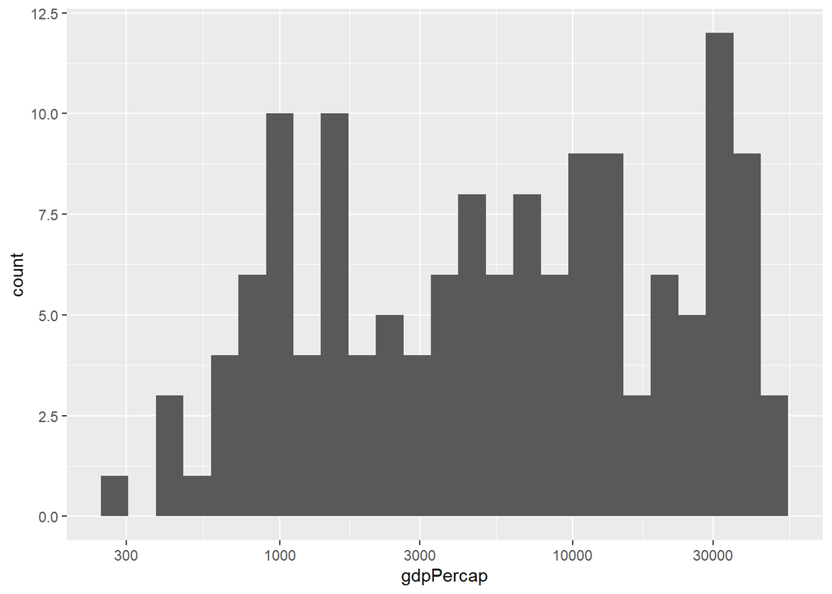

```r
gapminder %>% filter(year=="2007") %>%
  ggplot(aes(x=gdpPercap))+
  geom_histogram(bins=25)+
  scale_x_log10()
```

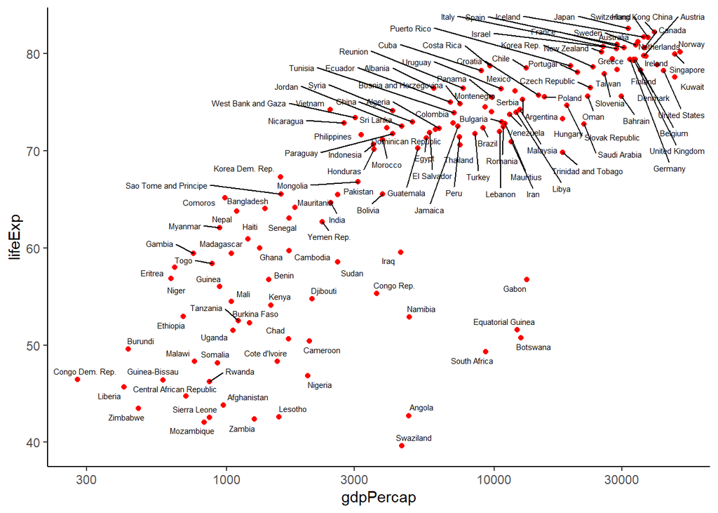

```r
library(ggrepel)
gapminder %>% filter(year=="2007") %>%
  ggplot(aes(x=gdpPercap,y=lifeExp))+
  geom_point(color="red")+scale_x_log10()+
  geom_text_repel(aes(label=country),size=2)+
  theme_classic()
```

ggplot2中可以使用中文，library(showtex)即可